# IODS course project

## Analysing the crime rates

### Creating a factory variable

Before we continue our analysis we must standardize our dataset by scaling it. The effect of this can be easily seen by comparing our earlier summary of the data with the summary below: The main difference is that all of the variables in our scaled variables have mean values of zero (0). Now we can more easily compare the variations, ranges, and constitutions between our variables, and, most importantly, plot their connections.

```r
scaledbos <- scale(Boston)
summary(scaledbos)
```

```
##       crim                 zn               indus
##  Min.   :-0.419367   Min.   :-0.48724   Min.   :-1.5563
##  1st Qu.:-0.410563   1st Qu.:-0.48724   1st Qu.:-0.8668
##  Median :-0.390280   Median :-0.48724   Median :-0.2109
##  Mean   : 0.000000   Mean   : 0.00000   Mean   : 0.0000
##  3rd Qu.: 0.007389   3rd Qu.: 0.04872   3rd Qu.: 1.0150
##  Max.   : 9.924110   Max.   : 3.80047   Max.   : 2.4202
##       chas              nox                rm               age
##  Min.   :-0.2723   Min.   :-1.4644   Min.   :-3.8764   Min.   :-2.3331
##  1st Qu.:-0.2723   1st Qu.:-0.9121   1st Qu.:-0.5681   1st Qu.:-0.8366
##  Median :-0.2723   Median :-0.1441   Median :-0.1084   Median : 0.3171
##  Mean   : 0.0000   Mean   : 0.0000   Mean   : 0.0000   Mean   : 0.0000
##  3rd Qu.:-0.2723   3rd Qu.: 0.5981   3rd Qu.: 0.4823   3rd Qu.: 0.9059
##  Max.   : 3.6648   Max.   : 2.7296   Max.   : 3.5515   Max.   : 1.1164
##       dis               rad               tax             ptratio
##  Min.   :-1.2658   Min.   :-0.9819   Min.   :-1.3127   Min.   :-2.7047
##  1st Qu.:-0.8049   1st Qu.:-0.6373   1st Qu.:-0.7668   1st Qu.:-0.4876
##  Median :-0.2790   Median :-0.5225   Median :-0.4642   Median : 0.2746
##  Mean   : 0.0000   Mean   : 0.0000   Mean   : 0.0000   Mean   : 0.0000
##  3rd Qu.: 0.6617   3rd Qu.: 1.6596   3rd Qu.: 1.5294   3rd Qu.: 0.8058
##  Max.   : 3.9566   Max.   : 1.6596   Max.   : 1.7964   Max.   : 1.6372
##      black             lstat              medv
##  Min.   :-3.9033   Min.   :-1.5296   Min.   :-1.9063
##  1st Qu.: 0.2049   1st Qu.:-0.7986   1st Qu.:-0.5989
##  Median : 0.3808   Median :-0.1811   Median :-0.1449
##  Mean   : 0.0000   Mean   : 0.0000   Mean   : 0.0000
##  3rd Qu.: 0.4332   3rd Qu.: 0.6024   3rd Qu.: 0.2683
##  Max.   : 0.4406   Max.   : 3.5453   Max.   : 2.9865
```

Now it’s time to concentrate on the per capita crime rate variable. Let’s start by creating a categorical value out of the crime variable of our new scaled dataset. We star by dividing our crime rate data into quantiles. The numbers are the same as in our latest summary minus the mean: ( Before that we must convert the data to a data frame format.)

```r
scaledbos <- as.data.frame(scaledbos)
quant <- quantile(scaledbos$crim)
quant
```

```
##           0%          25%          50%          75%         100%
## -0.419366929 -0.410563278 -0.390280295  0.007389247  9.924109610
```

Next we give names to our quantiles: Starting from the first (0-25%) the names of our new categories are “low”, “med_low” (25-50%), “med_high” (50-75%) and “high” (75-100%). Let’s take look how many observations fit under these categories:

```r
crime <- cut(scaledbos$crim, breaks = quant, include.lowest = TRUE, labels = c("low", "med_low", "med_high", "high"))
table(crime)
```

```
## crime
##      low  med_low med_high     high
##      127      126      126      127
```

### Training and testing

Before dividing our data into train and test sets, we have to remove our old continuous variable and add our new categorical variable into our (scaled) dataset.

```r
scaledbos <- dplyr::select(scaledbos, -crim)
scaledbos <- data.frame(scaledbos, crime)
```

Now we are ready to divide our prepared dataset into train and test sets. The train set will cover 80% of our data. The we remove the train set and the crime variable from our test set:

```r
n <- nrow(scaledbos)
ind <- sample(n,  size = n * 0.8)
train <- scaledbos[ind,]
test <- scaledbos[-ind,]
```

Now let’s fit the LDA (Linear Discriminant Analysis) on the train set. We have the categorical crime rate as our target variable and all the other variables as explanatory variables. The plot looks as follows:

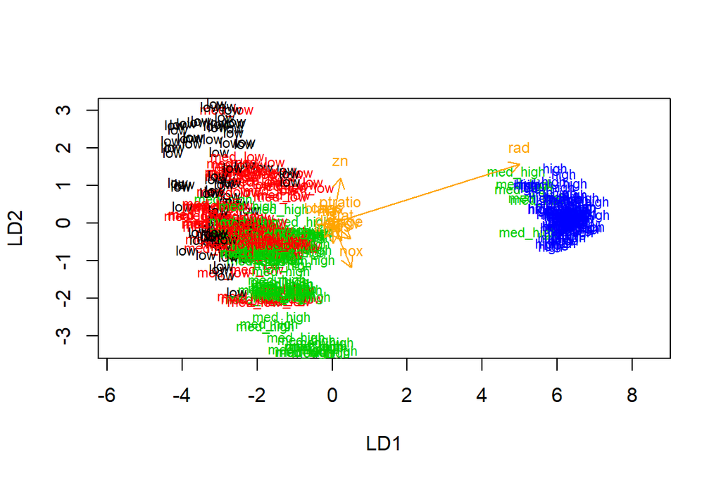

```r
lda.fit <- lda(crime ~ ., data = train)

lda.arrows <- function(x, myscale = 1, arrow_heads = 0.1, color = "orange", tex = 0.75, choices = c(1,2)){
  heads <- coef(x)
  arrows(x0 = 0, y0 = 0,
         x1 = myscale * heads[,choices[1]],
         y1 = myscale * heads[,choices[2]], col=color, length = arrow_heads)
  text(myscale * heads[,choices], labels = row.names(heads),
       cex = tex, col=color, pos=3)
}


classes <- as.numeric(train$crime)


plot(lda.fit, dimen = 2, col = classes, pch = classes)
lda.arrows(lda.fit, myscale = 1.6)
```

```r
correct_classes <- test$crime
test <- dplyr::select(test, -crime)

lda.pred <- predict(lda.fit, newdata = test)
tab <- table(correct = correct_classes, predicted = lda.pred$class)
tab
```

```
##           predicted
## correct    low med_low med_high high
##   low       14      12        2    0
##   med_low    4      15        9    0
##   med_high   0       9       14    0
##   high       0       0        1   22
```

The above table shows the test dataset’s correct results vs. predicted results based on our training set. As we can see, our prediction is spot on with the highest category of crime rates, but then the amount of misclassifications starts rising. In overall, our prediction succeeds better with the two higher categories, but, as our LDA plot shows, the remaining to categories and part of the second highest category are more a lot more harder to separate from each other. Let’s conclude by calculating our models accuracy:

```r
sum(diag(tab))/sum(tab)
```

```
## [1] 0.6372549
```

### K-means clustering

Let’s finish with doing some k-means clustering to find the optimal number of categories in our dataset. In order to do this, we return our original scaled dataset.

```r
library(MASS)
data("Boston")
```

And the we standardize…

```r
scaled <- scale(Boston)
```

…and calculate the Euclidean distances:

```r
dist_eu <- dist(scaled)
summary(dist_eu)
```

```
##    Min. 1st Qu.  Median    Mean 3rd Qu.    Max.
##  0.1343  3.4625  4.8241  4.9111  6.1863 14.3970
```

To find the optimal number of clusters within our dataset, we look at how the total of within cluster sum of squares (WCSS) reacts to the changement of clusters. In order to do this, we set our maximum number of clusters as ten (10). The point of this analysis is to see when the value of WCSS drastically drops. Here is the plot:

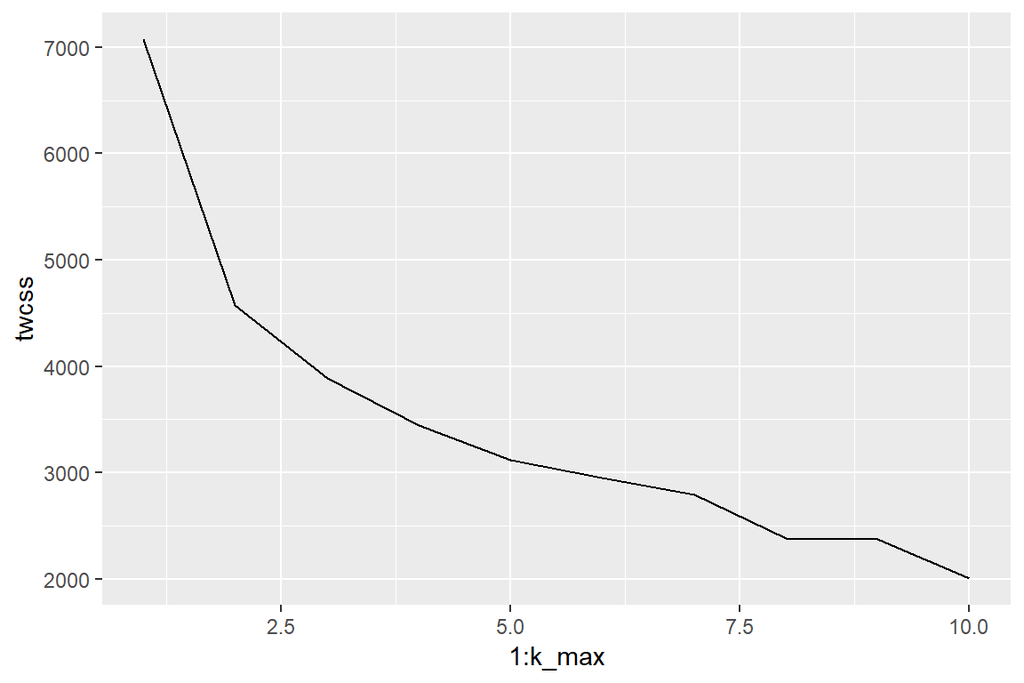

```r
library(ggplot2)
set.seed(123)
k_max <- 10
twcss <- sapply(1:k_max, function(k){kmeans(scaled, k)$tot.withinss})
qplot(x = 1:k_max, y = twcss, geom = 'line')
```

The plot above shows that the optimum number of clusters for our data is two (2). Let’s run k-means algorithm with two (cluster) centers on the dataset. To give a more clear view and underline our poin, we produce the plot matrix only partially:

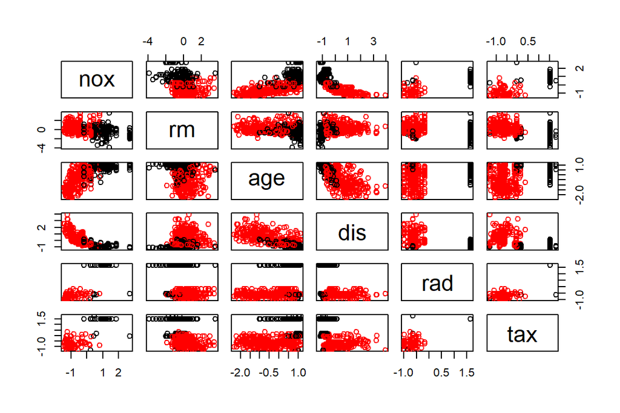

```r
scaled <- as.data.frame(scaled)
km <-kmeans(scaled, centers = 2)
pairs(scaled[5:10], col = km$cluster)
```

Just to underline this, we can finish our analysis with a plot matrix with three (3) clusters. This looks significantly more messy and unoptimal:

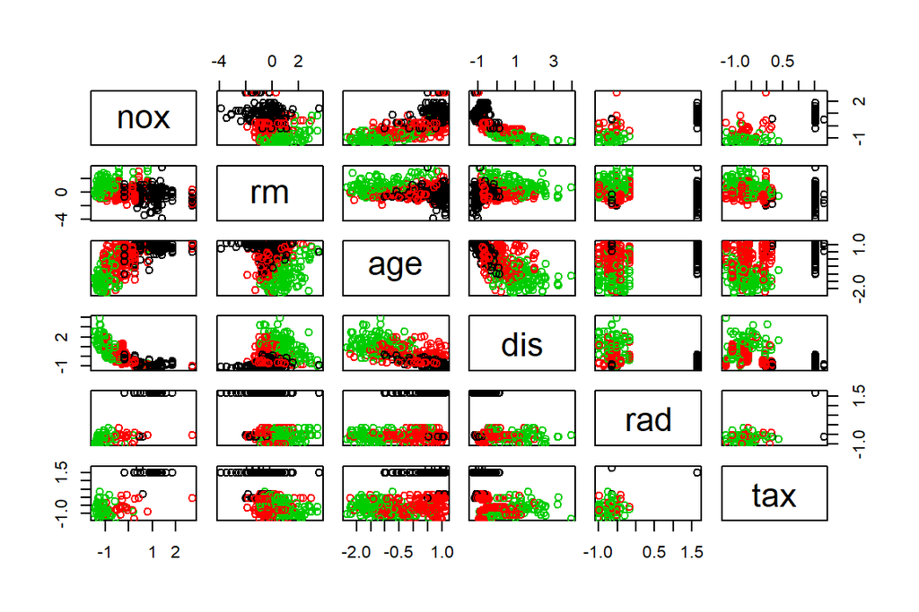

```r
scaled <- as.data.frame(scaled)
km <-kmeans(scaled, centers = 3)
pairs(scaled[5:10], col = km$cluster)
```